# BayesGrid

GB

06.03.2023

Exercise: Program a simple grid approximation to obtain a posterior distribution

Please download a copy of BayesGrid.Rmd and the data file arrival.csv into the same folder and fill in the relevant sections below.

To download the files follow the link and right-click anywhere on the page and the click “save as”.

# The data Data

Use this data about arrivals times relative to the start of a lecture.

```r
my_data =
  read.table(
    "arrival.csv",
    header = T,
    sep = ",")
head(my_data)
```

```
##   age time
## 1  31   -1
## 2  19    0
## 3  24   -1
## 4  23   -1
## 5  24   -5
## 6  21   -1
```

Here is the plot of the data

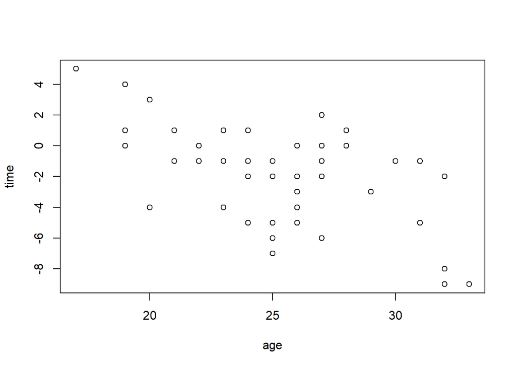

```r
with(my_data,
     plot(age, time))
```

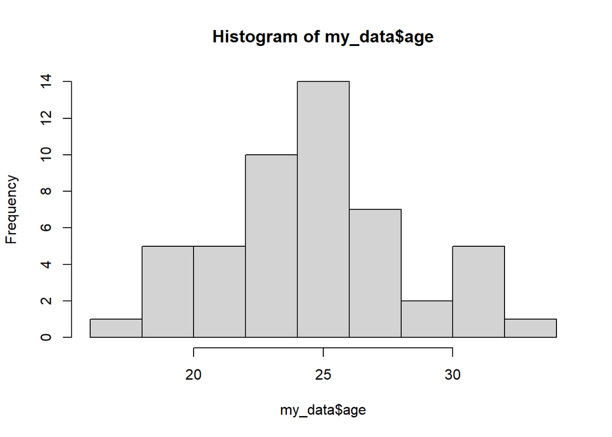

```r
hist(my_data$age)
```

Now add the centered age as a variable to `my_data` plot its histogram:

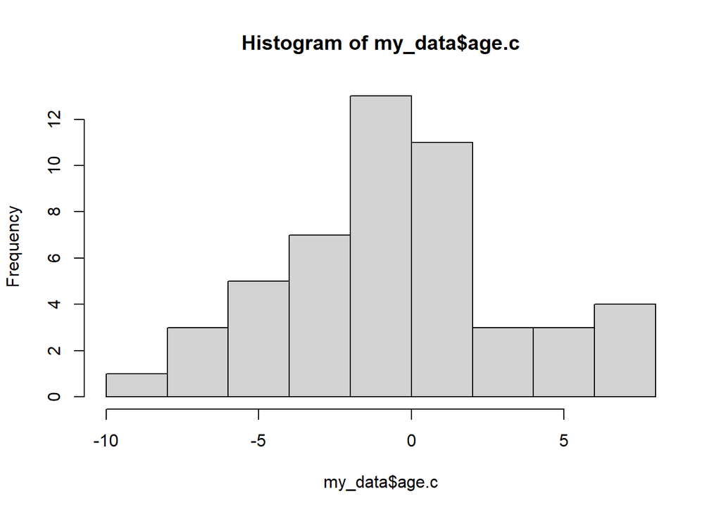

```r
my_data$age.c = my_data$age-mean(my_data$age)
hist(my_data$age.c)
```

# The Model

We want to estimate the effect of age on arrival time. The table shows the incomplete model expressed with equations, `quap` code fragments, and how one would calculate quantities directly in R.

| What | Notation | quap code | R code |
| --- | --- | --- | --- |
| Likelihood | $t_i \sim Normal(\mu_i,\sigma)$ | `time ~ dnorm(mu, sigma)` | `L = prod(dnorm(time, mu, sigma))` |
| linear model | $\mu = \alpha + \beta\textrm{age.c}$ | `mu[i] <- alpha + beta*age.c[i]` | `mu[i] <- alpha + b*age.c[i]` |
| Prior | $\alpha \sim Normal(0,3)$ | `alpha ~ dnorm(0, 3)` | `p_alpha = dnorm(alpha, 0, 3)` |
| Prior | $\beta \sim Normal(0,2)$ | `beta ~ dnorm(0, 2)` | `p_beta = dnorm(beta, 0, 2)` |
| Prior | $\sigma \sim halfNormal(0,2)$ | `sigma ~ dnorm(0, 2)` | `p_sigma = dnorm(sigma, 0, 2)` |

Because `quap` knows that sigma has to be positive, specifying `sigma ~ dnorm(0, 2)` implicitly means that a half-Normal distribution is used.

Your first task is to complete the model to do this. Please add the missing information in the table above. You need to add the parameter values to the prior for $\mu$ and you have to choose a distribution and parameter(s) for the standard deviation $\sigma$.

### The prior predictive distribution

To understand the implications of our priors, we simulate arrival times given the observed ages and paramter values drawn from the pior:

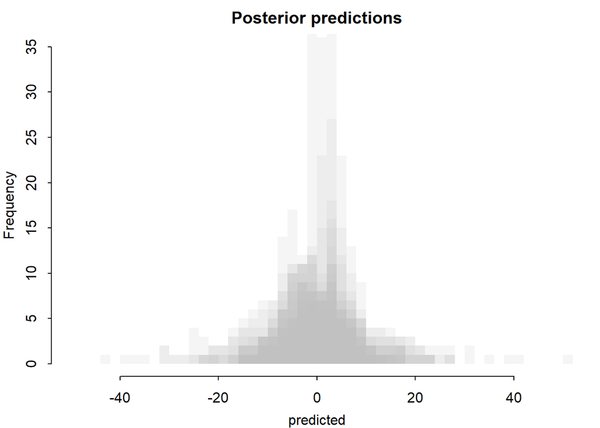

```r
par (mar=c(3,3,2,1), mgp=c(2,.7,0), tck=-.01)
for (k in 1:50) {
  alpha = rnorm(1,0,3)
  beta = rnorm(1,0,2)
  sigma = abs(rnorm(1,0,2))

  mu = alpha + my_data$age.c*beta
  predicted = rnorm(
    n = nrow(my_data),
    mean = mu,
    sd = sigma)
  hist(predicted,
       breaks = seq(-60,60,2),
       ylim = c(0,35),
       xlim = c(-50,50),
       add = ifelse(k==1,FALSE,TRUE),
       col = adjustcolor("grey",alpha = .15), border = NA,
       main = "Posterior predictions")
}
```

It is OK that the prior predictive distribution allows people to come very early or very late. What is important is that the arrival times at the start of the lecture have the highest probability and that people come minutes early or late and not hours or days.

### The posterior disribution

The posterior distribution is calculated as follows:

$$\overset{Posterior}{P(\mu,\sigma|w)} =
\frac{\prod_i \overset{Likelihood}{Normal(t_i|\mu_i,\sigma)} \cdot
\overset{Prior}{Normal(\alpha|0,3)Normal(\beta|0,2)Normal(\sigma|0,2)}}
{\overset{Evidence}{\int\int\int \prod_i Normal(t_i|\mu_i,\sigma) \cdot
Normal(\alpha|0,3)Normal(\beta|0,2)Normal(\sigma|0,2)d\alpha d\beta
d\sigma}}$$

Please add the missing information, using what you just added to the table, wherever are three dots $...$ or it reads $YourDist$.

### Calculate the likelihood for a data point

Let’s assume these parameter values

- `alpha = -1`
- `beta = .1`
- `sigma = 2`

Please calculate the likelihood for the first data point in the vector `time` in the next code block by using a centered version of the variable age (add this centered variable to the data.frame `my_data`.). If you are uncertain about how to proceed, check the table above.

```r
# Likelihood for the first data point
my_data$age.c = my_data$age - mean(my_data$age)
mu = -1 + my_data$age.c[1]*.1
dnorm(my_data$time[1],mu,2)
```

```
## [1] 0.1908648
```

Now calculate the probability of time given age and the parameter values for each recorded individual. You do not need a loop to do this!

```r
# Likelihoods for all individual data points
mu = -1 + my_data$age.c*.1
L = dnorm(my_data$time,mu,2)
L
```

```
##  [1] 1.908648e-01 1.444979e-01 1.991912e-01 1.984158e-01 2.997204e-02
##  [6] 1.954032e-01 9.166724e-02 1.153032e-01 1.426152e-02 1.994702e-01
## [11] 9.674369e-02 1.805062e-01 1.669117e-01 1.762961e-01 1.085667e-01
## [16] 1.717543e-01 7.517848e-02 1.576299e-02 6.098545e-04 1.762961e-01
## [21] 2.715782e-02 1.393467e-01 1.145791e-01 1.874224e-01 6.028390e-02
## [26] 9.744275e-02 1.572451e-05 1.984158e-01 1.800195e-01 1.263689e-05
## [31] 3.924602e-03 7.454963e-02 1.984158e-01 8.830089e-03 2.454640e-02
## [36] 1.994702e-01 1.985349e-01 1.611709e-01 1.839134e-01 1.954032e-01
## [41] 6.844635e-03 1.762961e-01 8.535039e-02 2.235947e-03 6.028390e-02
## [46] 1.991912e-01 1.219633e-04 1.934782e-01 1.971500e-01 1.386378e-01
```

And now calculate the joint probability of all recorded ages. (Read the help for the `prod` function, i.e. type `?prod`in the console)

```r
# Joint likelihood for all individual data points
L = prod(L)
L
```

```
## [1] 4.086976e-66
```

Now calculate the prior probability of the the parameters `alpha = -1`, `beta = .1` and `sigma = 3`. You should use the prior distributions you specified above for this.

```r
# Prior probability for alpha = -1
dnorm(1,0,3)
```

```
## [1] 0.1257944
```

```r
# Prior probability for beta = .1
dnorm(.1,0,2)
```

```
## [1] 0.199222
```

```r
# Prior probability for sigma = 3
dnorm(3,0,2)
```

```
## [1] 0.0647588
```

And the joint prior probability for `alpha = -1`, `beta = .1` and `sigma = 3`.

```r
# Joint prior probability for alpha = -1, beta = .1 and sigma = 3
P = dnorm(1,0,3)*dnorm(.1,0,2)*dnorm(3,0,2)
```

```r
# Joint probability of data and parameters for alpha = -1, beta = .1 and sigma = 3.
# given the prior distributions for alpha, beta and sigma
JP = L*P
```

# Grid approximation

Now that you have calculated the relative plausibility of data and parameters given the prior distributions for one set of parameters, you can do this for a larger number of parameters combinations, which we can generate by constructing a grid where each point is a combination of one `alpha`, `beta` and `sigma` parameter value.

First set up the grid. You can use the the code example below. Feel free to change the range of the parameters you explore by changing the first and second number in the `seq` commands

```r
# Here we are making our grid
# expand.grid produces all combinations
# of the N (here 3) variables submitted
# and puts them in a matrix with N columns
grid_resolution = 51
params =
  expand.grid(
    alpha = seq(-3, 3, length.out = grid_resolution),
    beta = seq(-1, 1, length.out = grid_resolution),
    sigma = seq(.01, 3, length.out = grid_resolution)
  )
params = data.frame(params)
head(params)
```

```
##   alpha beta sigma
## 1 -3.00   -1  0.01
## 2 -2.88   -1  0.01
## 3 -2.76   -1  0.01
## 4 -2.64   -1  0.01
## 5 -2.52   -1  0.01
## 6 -2.40   -1  0.01
```

```r
tail(params)
```

```
##        alpha beta sigma
## 132646  2.40    1     3
## 132647  2.52    1     3
## 132648  2.64    1     3
## 132649  2.76    1     3
## 132650  2.88    1     3
## 132651  3.00    1     3
```

### Unnormalized posterior (relative plausibility)

Now you can calculate the unnormalized posterior for all parameter combinations. It is easiest to use a for loops for this.

Store the result for each parameter combination in the the variable `UP`.

```r
params$UP = NA
for (k in 1:nrow(params)) {
  a = params$alpha[k]
  b = params$beta[k]
  sig = params$sigma[k]
  mu = a + b*my_data$age.c
  P_params = dnorm(a,0,3)*dnorm(b,0,2)*dnorm(sig,0,2)
  likelihood = prod(dnorm(my_data$time,mu,sig))
  params$UP[k] = P_params*likelihood
}
```

### Calculate the evidence

Use the data.frame `params` that you just created, specifically one column in it, to calculate the *evidence*. If you are uncertain, check the equation above

[figure not shown]

```r
# Calculate the evidence from the unnormalized posterior
evidence = sum(params$UP)
```

### Normalize to get a proper posterior distribution.

Now you can use the evidence to add a one more column to the `params` data frame, let’s call it `PP`, which has the posterior probability for each parameter combination.

```r
# Calculate posterior probabilities
params$PP = params$UP/evidence
```

### Sample the posterior

```r
# We are sampling indexes and then
# use indexes to get samples
post.idx = sample(1:nrow(params), 10000, prob = params$PP, replace = TRUE)
posterior = params[post.idx, c("alpha","beta","sigma")]
```

### Plot the posterior

Next we plot the marginal posterior distributions of the parameters with a histogram or density plot: Here, you should use the `sample` command to generate a posterior distribution for each variable

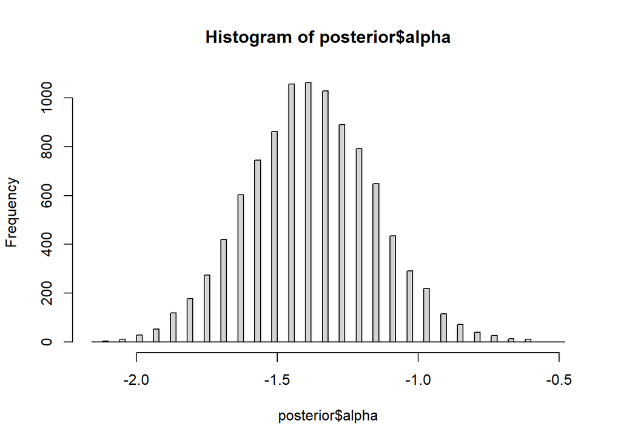

```r
## marginal posterior distribution for alpha
hist(posterior$alpha, breaks = 100)
```

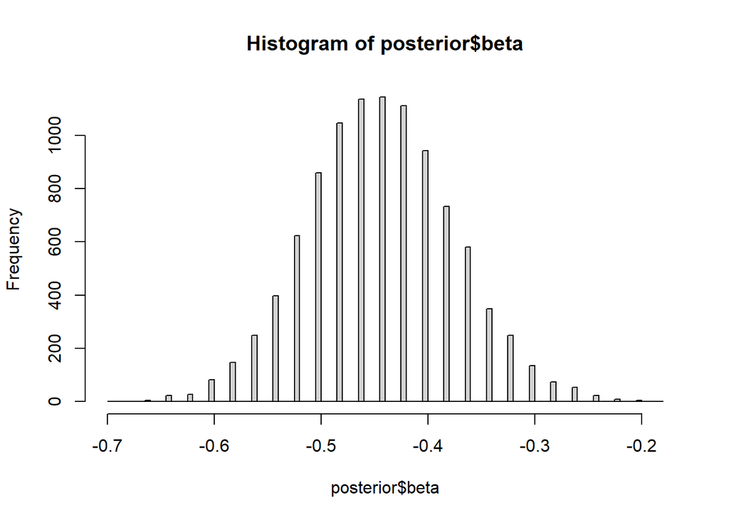

```r
## marginal posterior distribution for beta
hist(posterior$beta, breaks = 100)
```

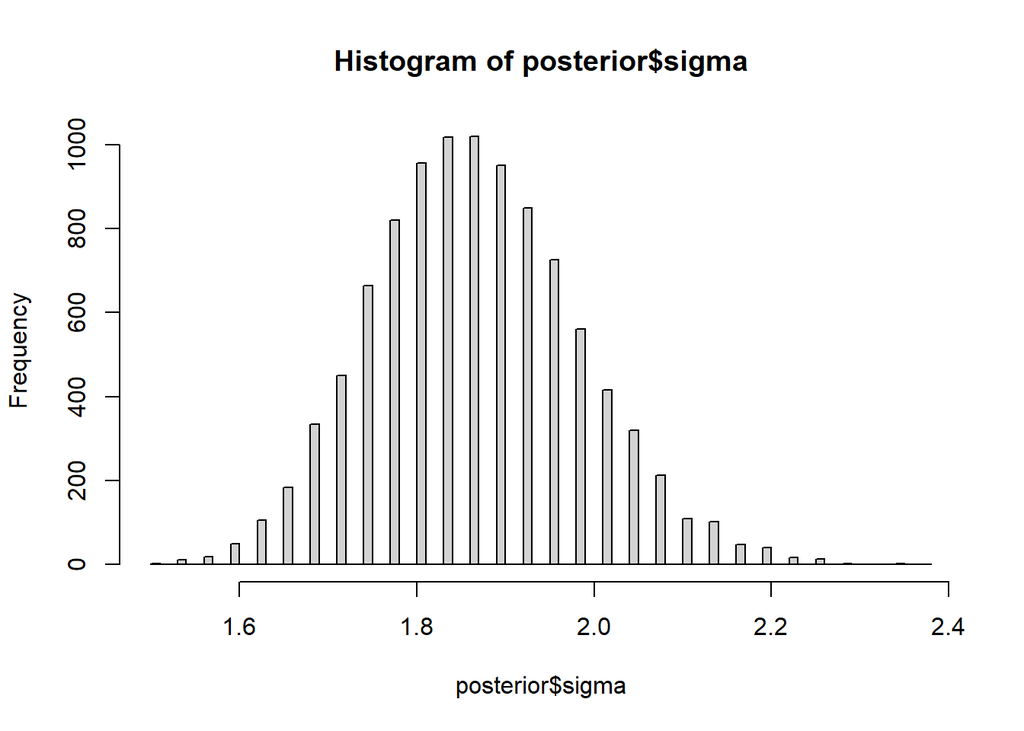

```r
## marginal posterior distribution for sigma
hist(posterior$sigma, breaks = 100)
```

If you find that these posteriors look very coarse, you can go back and increase the value for `grid_resolution` but things might get very slow if you go above 50.

```r
library(rethinking)
mean(posterior$alpha)
```

```
## [1] -1.370928
```

```r
HPDI(posterior$alpha,prob = c(.9))
```

```
##  |0.9  0.9|
## -1.74 -1.02
```

```r
mean(posterior$beta)
```

```
## [1] -0.4417
```

```r
HPDI(posterior$beta,prob = c(.9))
```

```
##  |0.9  0.9|
## -0.56 -0.34
```

```r
mean(posterior$sigma)
```

```
## [1] 1.865286
```

```r
HPDI(posterior$sigma,prob = c(.9))
```

```
##   |0.9   0.9|
## 1.6844 2.0432
```

Now make a 2-D plots of the posterior. Do you see if some of the parameters are correlated?

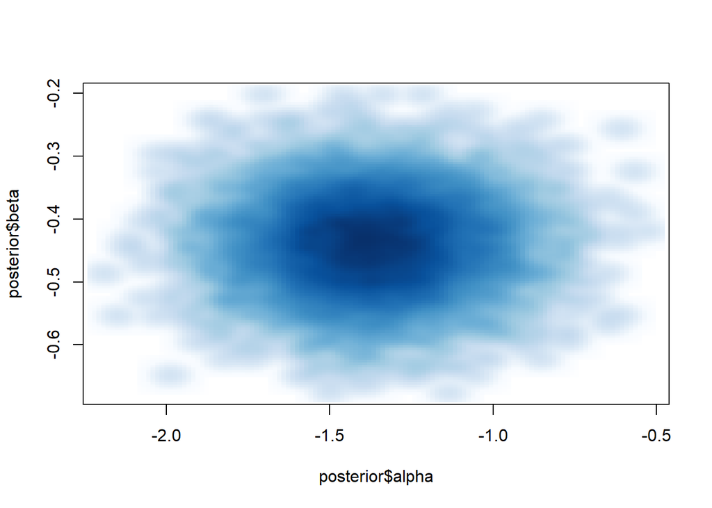

```r
# use smoothScatter to plot the joint distribution
smoothScatter(posterior$alpha, posterior$beta, nrpoints = 0)
```

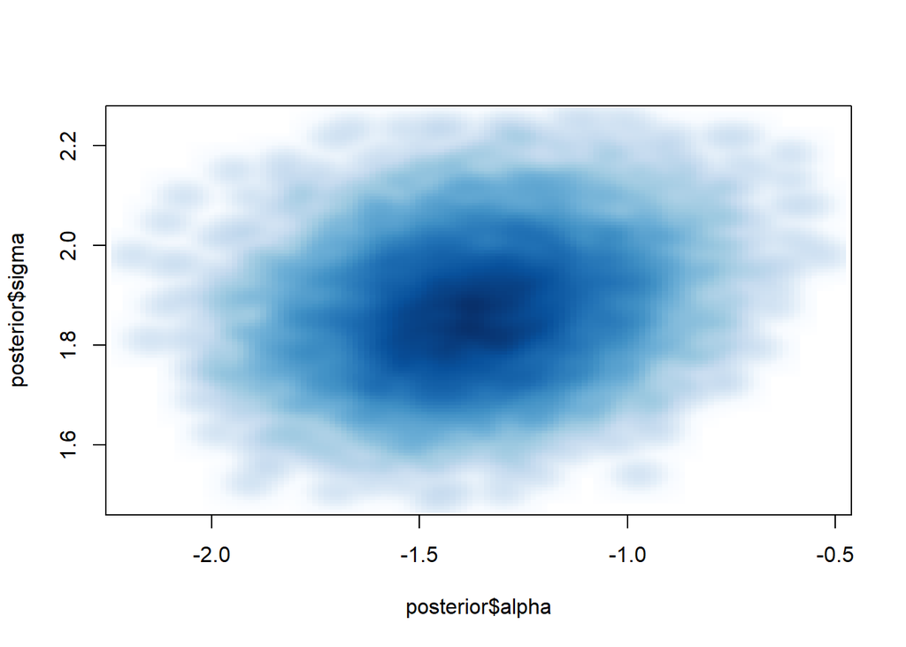

```r
smoothScatter(posterior$alpha, posterior$sigma, nrpoints = 0)
```

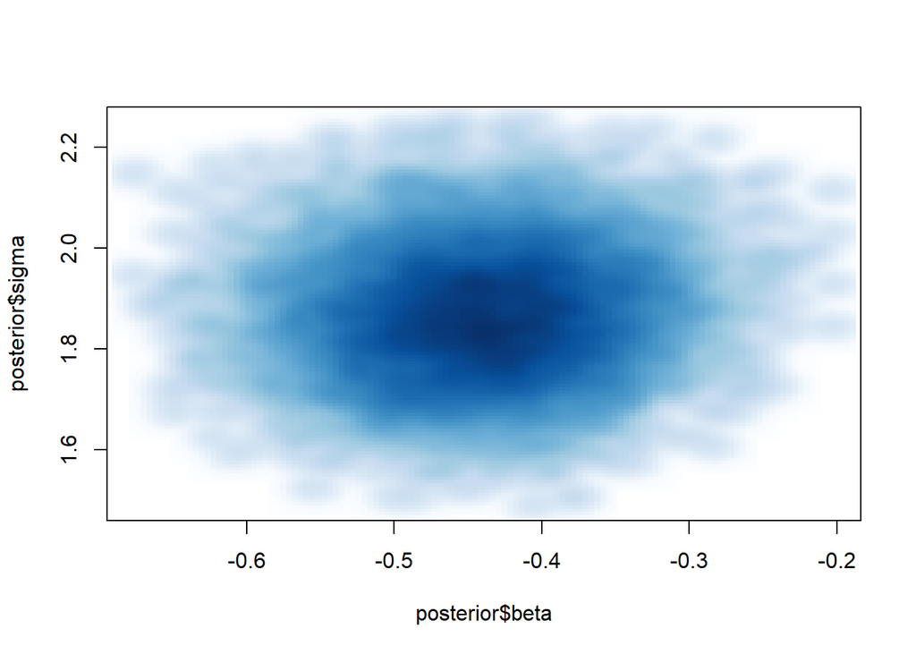

```r
smoothScatter(posterior$beta, posterior$sigma, nrpoints = 0)
```

```r
library(magrittr)
```

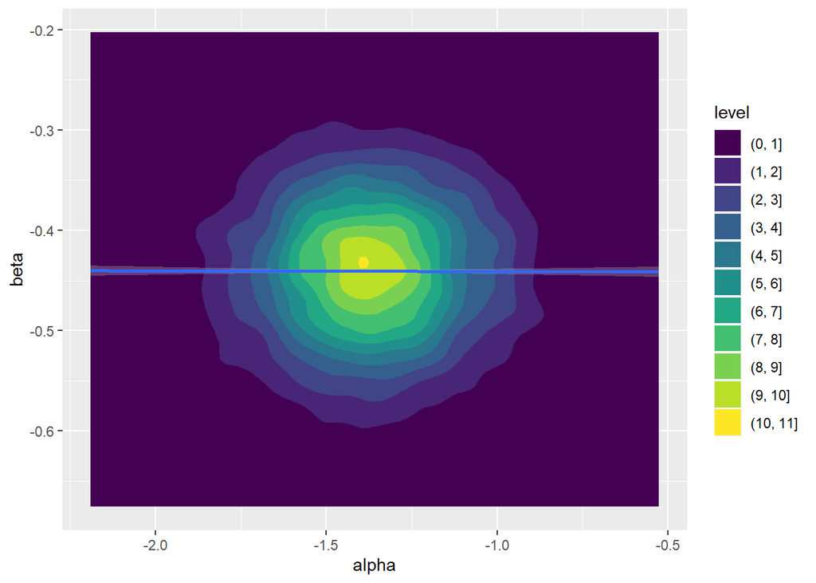

```r
library(ggplot2)
posterior %>%
  ggplot(aes(x = alpha, y = beta)) +
  geom_density_2d_filled() +
    geom_smooth(method = "lm")
```

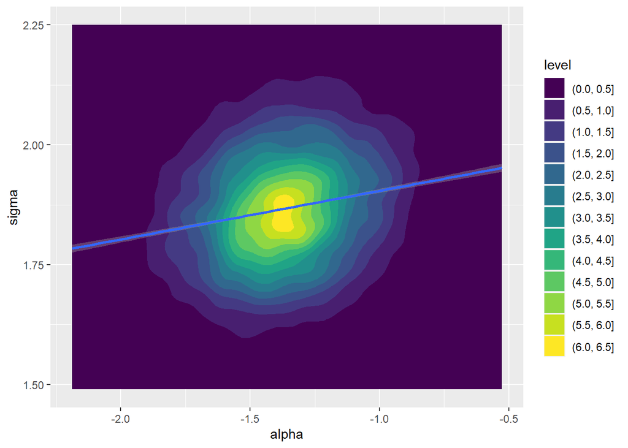

```r
posterior %>%
    ggplot(aes(x = alpha, y = sigma)) +
    geom_density_2d_filled() +
    geom_smooth(method = "lm")
```

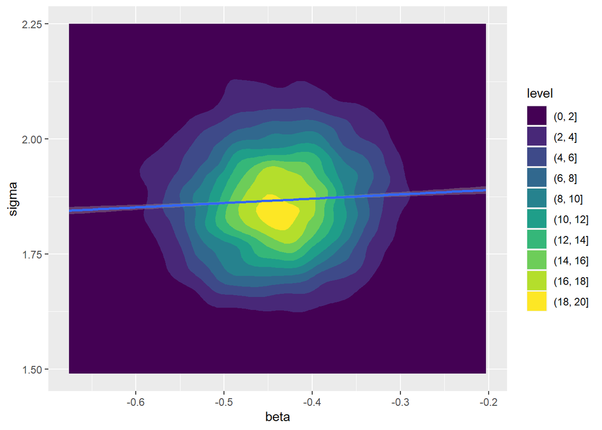

```r
posterior %>%
    ggplot(aes(x = beta, y = sigma)) +
    geom_density_2d_filled() +
    geom_smooth(method = "lm")
```

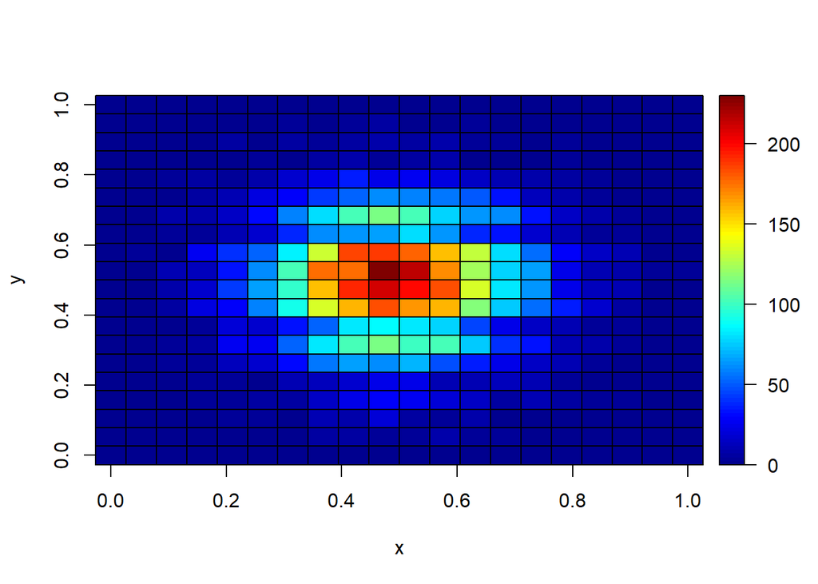

```r
library(plot3D)

##  Create cuts:
alpha_c <- cut(posterior$alpha, 20)
beta_c <- cut(posterior$beta, 20)
sigma_c <- cut(posterior$sigma, 20)

##  Calculate joint counts at cut levels:
z <- table(alpha_c, beta_c)

##  Plot as a 2D heatmap:
image2D(z=z, border="black")
```

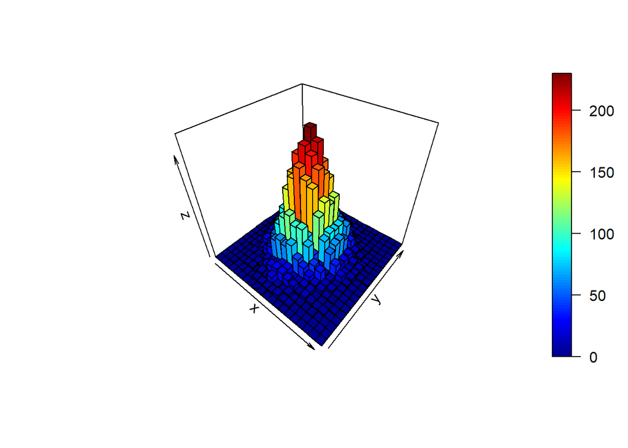

```r
##  Plot as a 3D histogram:
hist3D(z=z, border="black")
```